# Probabilistic Forecasting: Global Models

Skforecast allows applying all its implemented probabilistic forecasting methods (bootstrapping, conformal prediction and quantile regression) to global models. A global model, such as [`ForecasterRecursiveMultiSeries`](https://skforecast.org/latest/api/forecasterrecursivemultiseries), is a single model trained with the observations of all the available time series, which can then forecast any of them, and even series not seen during training. This guide shows how to estimate prediction intervals for multiple series with conformal prediction and bootstrapped residuals.

For detailed information about the available probabilistic forecasting methods, see the following user guides:

- Probabilistic forecasting: Overview
- Probabilistic forecasting: Bootstrapped residuals
- Probabilistic forecasting: Conformal prediction
- Probabilistic forecasting: Conformal calibration
- Probabilistic forecasting: Quantile regression

**💡 Tip**

When predicting multiple series and scaling up to hundreds or thousands of series, computational time can become a bottleneck. In such cases, the **conformal framework** is a good option, since it is usually faster than the other methods: it does not need to simulate `n_boot` prediction paths (bootstrapping), nor to train one model per quantile (quantile regression).

## Libraries and data

```python
# Data processing
# ==============================================================================
import numpy as np
import pandas as pd
from skforecast.datasets import fetch_dataset

# Plots
# ==============================================================================
import matplotlib.pyplot as plt
from skforecast.plot import set_dark_theme, plot_prediction_intervals
from statsmodels.graphics.tsaplots import plot_pacf

# Modelling and Forecasting
# ==============================================================================
from sklearn.preprocessing import OneHotEncoder
from sklearn.compose import ColumnTransformer
from lightgbm import LGBMRegressor
from skforecast.recursive import ForecasterRecursiveMultiSeries
from skforecast.model_selection import TimeSeriesFold, backtesting_forecaster_multiseries
from skforecast.metrics import calculate_coverage
from skforecast.stats import calculate_lag_autocorrelation

# Configuration
# ==============================================================================
import warnings
from pprint import pprint
warnings.filterwarnings('once')
```

# Data processing # ============================================================================== import numpy as np import pandas as pd from skforecast.datasets import fetch_dataset # Plots # ============================================================================== import matplotlib.pyplot as plt from skforecast.plot import set_dark_theme, plot_prediction_intervals from statsmodels.graphics.tsaplots import plot_pacf # Modelling and Forecasting # ============================================================================== from sklearn.preprocessing import OneHotEncoder from sklearn.compose import ColumnTransformer from lightgbm import LGBMRegressor from skforecast.recursive import ForecasterRecursiveMultiSeries from skforecast.model_selection import TimeSeriesFold, backtesting_forecaster_multiseries from skforecast.metrics import calculate_coverage from skforecast.stats import calculate_lag_autocorrelation # Configuration # ============================================================================== import warnings from pprint import pprint warnings.filterwarnings('once')

```python
# Data
# ==============================================================================
data = fetch_dataset(name="bdg2_hourly_sample")
data = data.loc['2016-01-01 00:00:00' : '2016-09-30 00:00:00', :]
series = ['building_1', 'building_2']
data.head(2)
```

# Data # ============================================================================== data = fetch_dataset(name="bdg2_hourly_sample") data = data.loc['2016-01-01 00:00:00' : '2016-09-30 00:00:00', :] series = ['building_1', 'building_2'] data.head(2)

```
╭────────────────────────────── bdg2_hourly_sample ───────────────────────────────╮
│ Description:                                                                    │
│ Hourly energy consumption data of two buildings sampled from the The Building   │
│ Data Genome Project 2. https://github.com/buds-lab/building-data-genome-        │
│ project-2                                                                       │
│                                                                                 │
│ Source:                                                                         │
│ Miller, C., Kathirgamanathan, A., Picchetti, B. et al. The Building Data Genome │
│ Project 2, energy meter data from the ASHRAE Great Energy Predictor III         │
│ competition. Sci Data 7, 368 (2020). https://doi.org/10.1038/s41597-020-00712-x │
│                                                                                 │
│ URL:                                                                            │
│ https://raw.githubusercontent.com/skforecast/skforecast-                        │
│ datasets/main/data/bdg2_hourly_sample.csv                                       │
│                                                                                 │
│ Shape: 6553 rows x 2 columns                                                    │
╰─────────────────────────────────────────────────────────────────────────────────╯
```

| timestamp | building_1 | building_2 |
| --- | --- | --- |
| 2016-01-01 00:00:00 | 186.532 | 219.27 |
| 2016-01-01 01:00:00 | 186.532 | 219.27 |

The day of the week and the hour of the day are used as exogenous variables to capture the weekly and daily patterns of energy consumption. Both are one-hot encoded, so that each category becomes a binary column. Since calendar features are deterministic and known in advance for any date, encoding them with the whole dataset does not leak information from the future.

```python
# Calendar features
# ==============================================================================
data['day_of_week'] = data.index.dayofweek
data['hour'] = data.index.hour

transformer = ColumnTransformer(
    transformers=[
        ('one_hot_encoder', OneHotEncoder(sparse_output=False), ['day_of_week', 'hour'])
    ],
    remainder='passthrough',
    verbose_feature_names_out=False
).set_output(transform='pandas')

data = transformer.fit_transform(data)
data.head()
```

# Calendar features # ============================================================================== data['day_of_week'] = data.index.dayofweek data['hour'] = data.index.hour transformer = ColumnTransformer( transformers=[ ('one_hot_encoder', OneHotEncoder(sparse_output=False), ['day_of_week', 'hour']) ], remainder='passthrough', verbose_feature_names_out=False ).set_output(transform='pandas') data = transformer.fit_transform(data) data.head()

| timestamp | day_of_week_0 | day_of_week_1 | day_of_week_2 | day_of_week_3 | day_of_week_4 | day_of_week_5 | day_of_week_6 | hour_0 | hour_1 | hour_2 | ... | hour_16 | hour_17 | hour_18 | hour_19 | hour_20 | hour_21 | hour_22 | hour_23 | building_1 | building_2 |
| --- | --- | --- | --- | --- | --- | --- | --- | --- | --- | --- | --- | --- | --- | --- | --- | --- | --- | --- | --- | --- | --- |
| 2016-01-01 00:00:00 | 0.0 | 0.0 | 0.0 | 0.0 | 1.0 | 0.0 | 0.0 | 1.0 | 0.0 | 0.0 | ... | 0.0 | 0.0 | 0.0 | 0.0 | 0.0 | 0.0 | 0.0 | 0.0 | 186.532 | 219.270 |
| 2016-01-01 01:00:00 | 0.0 | 0.0 | 0.0 | 0.0 | 1.0 | 0.0 | 0.0 | 0.0 | 1.0 | 0.0 | ... | 0.0 | 0.0 | 0.0 | 0.0 | 0.0 | 0.0 | 0.0 | 0.0 | 186.532 | 219.270 |
| 2016-01-01 02:00:00 | 0.0 | 0.0 | 0.0 | 0.0 | 1.0 | 0.0 | 0.0 | 0.0 | 0.0 | 1.0 | ... | 0.0 | 0.0 | 0.0 | 0.0 | 0.0 | 0.0 | 0.0 | 0.0 | 183.479 | 218.348 |
| 2016-01-01 03:00:00 | 0.0 | 0.0 | 0.0 | 0.0 | 1.0 | 0.0 | 0.0 | 0.0 | 0.0 | 0.0 | ... | 0.0 | 0.0 | 0.0 | 0.0 | 0.0 | 0.0 | 0.0 | 0.0 | 184.303 | 220.003 |
| 2016-01-01 04:00:00 | 0.0 | 0.0 | 0.0 | 0.0 | 1.0 | 0.0 | 0.0 | 0.0 | 0.0 | 0.0 | ... | 0.0 | 0.0 | 0.0 | 0.0 | 0.0 | 0.0 | 0.0 | 0.0 | 183.657 | 217.731 |

5 rows × 33 columns

```python
# Plot time series
# ==============================================================================
set_dark_theme()
plt.rcParams['lines.linewidth'] = 0.5
colors = plt.rcParams['axes.prop_cycle'].by_key()['color']
fig, axs = plt.subplots(2, 1, figsize=(7, 4), sharex=True)
for i, col in enumerate(series):
    axs[i].plot(data[col], label=col, color=colors[i])
    axs[i].legend(loc='lower left', fontsize=8)
    axs[i].tick_params(axis='both', labelsize=8)

plt.tight_layout()
```

# Plot time series # ============================================================================== set_dark_theme() plt.rcParams['lines.linewidth'] = 0.5 colors = plt.rcParams['axes.prop_cycle'].by_key()['color'] fig, axs = plt.subplots(2, 1, figsize=(7, 4), sharex=True) for i, col in enumerate(series): axs[i].plot(data[col], label=col, color=colors[i]) axs[i].legend(loc='lower left', fontsize=8) axs[i].tick_params(axis='both', labelsize=8) plt.tight_layout()

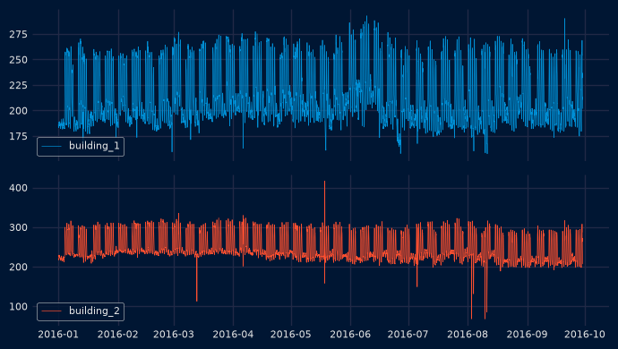

## Lag selection

The partial autocorrelation function (PACF) measures the correlation between a series and its lag $k$ after removing the effect of the intermediate lags ($1$ to $k-1$). Lags with a high absolute partial autocorrelation carry information that the previous lags do not, so they are good candidates for predictors. The partial autocorrelation of each building is calculated up to one week ($7 \times 24 = 168$ lags) with [`calculate_lag_autocorrelation`](https://skforecast.org/latest/api/stats#skforecast.stats._autocorrelation.calculate_lag_autocorrelation), and the 10 lags with the highest absolute value are selected for each series. Since a global model uses the same lags for all the series, the union of both sets is used as predictors.

```python
# Partial autocorrelation values and plots
# ==============================================================================
n_lags = 7 * 24
pacf_dfs = []

fig, axs = plt.subplots(2, 1, figsize=(6, 3))
for i, col in enumerate(series):
    pacf_values = calculate_lag_autocorrelation(data[col], n_lags=n_lags)
    pacf_values['variable'] = col
    pacf_dfs.append(pacf_values)

    plot_pacf(data[col], lags=n_lags, ax=axs[i])
    axs[i].set_title(col, fontsize=10)
    axs[i].set_ylim(-0.5, 1.1)

plt.tight_layout()
```

# Partial autocorrelation values and plots # ============================================================================== n_lags = 7 * 24 pacf_dfs = [] fig, axs = plt.subplots(2, 1, figsize=(6, 3)) for i, col in enumerate(series): pacf_values = calculate_lag_autocorrelation(data[col], n_lags=n_lags) pacf_values['variable'] = col pacf_dfs.append(pacf_values) plot_pacf(data[col], lags=n_lags, ax=axs[i]) axs[i].set_title(col, fontsize=10) axs[i].set_ylim(-0.5, 1.1) plt.tight_layout()

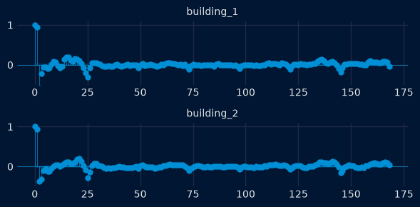

```python
# Top n lags with highest absolute partial autocorrelation per variable
# ==============================================================================
n = 10
top_lags = set()
for pacf_values in pacf_dfs:
    variable = pacf_values['variable'].iloc[0]
    lags = pacf_values.nlargest(n, 'partial_autocorrelation_abs')['lag'].sort_values().tolist()
    top_lags.update(lags)
    print(f"{variable}: {lags}")

top_lags = sorted(top_lags)
print(f"\nAll lags: {top_lags}")
```

# Top n lags with highest absolute partial autocorrelation per variable # ============================================================================== n = 10 top_lags = set() for pacf_values in pacf_dfs: variable = pacf_values['variable'].iloc[0] lags = pacf_values.nlargest(n, 'partial_autocorrelation_abs')['lag'].sort_values().tolist() top_lags.update(lags) print(f"{variable}: {lags}") top_lags = sorted(top_lags) print(f"\nAll lags: {top_lags}")

```
building_1: [1, 2, 3, 15, 16, 19, 20, 24, 25, 145]
building_2: [1, 2, 3, 20, 21, 22, 25, 26, 141, 145]

All lags: [1, 2, 3, 15, 16, 19, 20, 21, 22, 24, 25, 26, 141, 145]
```

The target series exhibit similar dynamics, and the selected lags can be grouped into three blocks:

- Lags 1 to 3: the consumption of the last few hours (short-term inertia).
- Lags 15 to 26: values from the previous 15 to 26 hours, mostly around 24 hours, which capture the daily cycle.
- Lags 141 and 145: values from around six days before, related to the weekly pattern.

The union of the lags selected for both series contains 14 lags, which are used as predictors by the global model.

For simplicity, the partial autocorrelation is calculated with the whole dataset. In a strict evaluation, lag selection should use only the training data, since otherwise information from the test period influences the design of the model.

## Train, validation and test partitions

The data is split into three consecutive partitions, each with a different role:

- **Train**: used to fit the forecaster.
- **Validation (calibration)**: the forecaster, trained only with the training data, predicts this period through backtesting. The errors made (out-of-sample residuals) are used later to build the prediction intervals.
- **Test**: used to evaluate the coverage and width of the prediction intervals on data not involved in any of the previous steps.

Label-based slicing with `.loc` includes both ends. The end dates are set to `23:59`, a time that does not exist in the hourly index, so that consecutive partitions do not share any observation.

```python
# Split train-validation-test
# ==============================================================================
end_train = '2016-07-01 23:59:00'
end_validation = '2016-09-01 23:59:00'
data_train = data.loc[: end_train, :]
data_val   = data.loc[end_train:end_validation, :]
data_test  = data.loc[end_validation:, :]

print(f"Dates train      : {data_train.index.min()} --- {data_train.index.max()}  (n={len(data_train)})")
print(f"Dates validation : {data_val.index.min()} --- {data_val.index.max()}  (n={len(data_val)})")
print(f"Dates test       : {data_test.index.min()} --- {data_test.index.max()}  (n={len(data_test)})")
```

# Split train-validation-test # ============================================================================== end_train = '2016-07-01 23:59:00' end_validation = '2016-09-01 23:59:00' data_train = data.loc[: end_train, :] data_val = data.loc[end_train:end_validation, :] data_test = data.loc[end_validation:, :] print(f"Dates train : {data_train.index.min()} --- {data_train.index.max()} (n={len(data_train)})") print(f"Dates validation : {data_val.index.min()} --- {data_val.index.max()} (n={len(data_val)})") print(f"Dates test : {data_test.index.min()} --- {data_test.index.max()} (n={len(data_test)})")

```
Dates train      : 2016-01-01 00:00:00 --- 2016-07-01 23:00:00  (n=4392)
Dates validation : 2016-07-02 00:00:00 --- 2016-09-01 23:00:00  (n=1488)
Dates test       : 2016-09-02 00:00:00 --- 2016-09-30 00:00:00  (n=673)
```

```python
# Plot partitions
# ==============================================================================
fig, axs = plt.subplots(2, 1, figsize=(7, 5), sharex=True)
for i, col in enumerate(series):
    axs[i].plot(data[col], label=col, color=colors[i])
    axs[i].legend(loc='lower left', fontsize=8)
    axs[i].tick_params(axis='both', labelsize=8)
    axs[i].axvline(pd.to_datetime(end_train), color='white', linestyle='--', linewidth=1)  # End train
    axs[i].axvline(pd.to_datetime(end_validation), color='white', linestyle='--', linewidth=1)  # End validation

plt.tight_layout()
```

# Plot partitions # ============================================================================== fig, axs = plt.subplots(2, 1, figsize=(7, 5), sharex=True) for i, col in enumerate(series): axs[i].plot(data[col], label=col, color=colors[i]) axs[i].legend(loc='lower left', fontsize=8) axs[i].tick_params(axis='both', labelsize=8) axs[i].axvline(pd.to_datetime(end_train), color='white', linestyle='--', linewidth=1) # End train axs[i].axvline(pd.to_datetime(end_validation), color='white', linestyle='--', linewidth=1) # End validation plt.tight_layout()

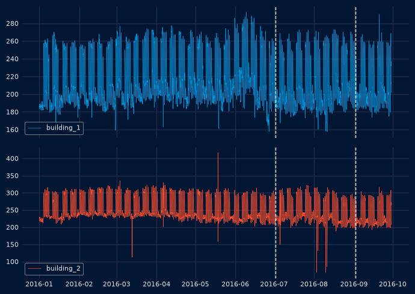

## Forecaster

A [`ForecasterRecursiveMultiSeries`](https://skforecast.org/latest/api/forecasterrecursivemultiseries) is created with a LightGBM regressor. It is a global model: a single estimator is trained with the observations of both buildings, using the 14 lags selected above as predictors. With `encoding='ordinal'`, the identifier of each series is added as an extra feature (encoded as an integer), so that the model can learn patterns specific to each building. The one-hot encoded calendar features are passed as exogenous variables.

```python
# Create forecaster
# ==============================================================================
exog_features = data.columns[data.columns.str.contains('day_of_|hour_')].tolist()

params = {
    "n_estimators": 300,
    "learning_rate": 0.05,
    "max_depth": 5,
}
forecaster = ForecasterRecursiveMultiSeries(
                 estimator = LGBMRegressor(random_state=15926, verbose=-1, **params),
                 lags      = top_lags,
                 encoding  = 'ordinal',
             )
```

# Create forecaster # ============================================================================== exog_features = data.columns[data.columns.str.contains('day_of_|hour_')].tolist() params = { "n_estimators": 300, "learning_rate": 0.05, "max_depth": 5, } forecaster = ForecasterRecursiveMultiSeries( estimator = LGBMRegressor(random_state=15926, verbose=-1, **params), lags = top_lags, encoding = 'ordinal', )

## Out-of-sample residuals

To estimate prediction intervals that reflect the errors expected on new data, the residuals must be out-of-sample, that is, generated by a model that did not see those observations during training. They are obtained by running a backtesting over the validation partition with [`backtesting_forecaster_multiseries`](https://skforecast.org/latest/api/model_selection#skforecast.model_selection._validation.backtesting_forecaster_multiseries). The folds are defined with [`TimeSeriesFold`](https://skforecast.org/latest/api/model_selection#skforecast.model_selection._split.TimeSeriesFold): the forecaster is trained with the training data only (`initial_train_size = len(data_train)`), and the validation period is predicted in folds of 24 steps (one day) without refitting. As a result, the residuals contain the errors of steps 1 to 24 of the forecast horizon, the same horizon used later on the test set.

```python
# Backtesting on validation data to obtain out-of-sample residuals
# ==============================================================================
cv = TimeSeriesFold(
    initial_train_size = len(data_train),
    steps              = 24,
)

metric_val, predictions_val = backtesting_forecaster_multiseries(
    forecaster = forecaster,
    series     = data.loc[:end_validation, series],
    exog       = data.loc[:end_validation, exog_features],
    cv         = cv,
    metric     = "mean_absolute_error"
)
metric_val
```

# Backtesting on validation data to obtain out-of-sample residuals # ============================================================================== cv = TimeSeriesFold( initial_train_size = len(data_train), steps = 24, ) metric_val, predictions_val = backtesting_forecaster_multiseries( forecaster = forecaster, series = data.loc[:end_validation, series], exog = data.loc[:end_validation, exog_features], cv = cv, metric = "mean_absolute_error" ) metric_val

[output not shown]

100%62/62 [00:00<00:00, 428.06it/s]

|  | levels | mean_absolute_error |
| --- | --- | --- |
| 0 | building_1 | 6.564278 |
| 1 | building_2 | 9.104094 |
| 2 | average | 7.834186 |
| 3 | weighted_average | 7.834186 |
| 4 | pooling | 7.834186 |

```python
# Plot predictions on validation data
# ==============================================================================
fig, axs = plt.subplots(2, 1, figsize=(7, 5.5), sharex=True, sharey=False)
for i, level in enumerate(predictions_val['level'].unique()):
    predictions_val_level = predictions_val.loc[predictions_val['level'] == level, 'pred']
    data.loc[end_train:end_validation, level].plot(ax=axs[i], label='Real value')
    predictions_val_level.plot(ax=axs[i], label='Prediction')
    axs[i].set_xlabel("")
    axs[i].set_title(level)
    axs[i].legend(loc='lower right', fontsize=7)

plt.tight_layout()
```

# Plot predictions on validation data # ============================================================================== fig, axs = plt.subplots(2, 1, figsize=(7, 5.5), sharex=True, sharey=False) for i, level in enumerate(predictions_val['level'].unique()): predictions_val_level = predictions_val.loc[predictions_val['level'] == level, 'pred'] data.loc[end_train:end_validation, level].plot(ax=axs[i], label='Real value') predictions_val_level.plot(ax=axs[i], label='Prediction') axs[i].set_xlabel("") axs[i].set_title(level) axs[i].legend(loc='lower right', fontsize=7) plt.tight_layout()

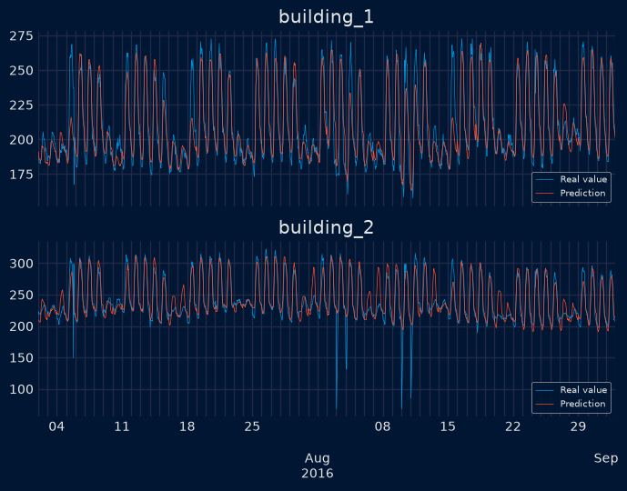

```python
# Out-of-sample residuals over time
# ==============================================================================
fig, axs = plt.subplots(2, 1, figsize=(7, 4), sharex=True, sharey=False)
for i, level in enumerate(predictions_val["level"].unique()):
    residuals = (
        data.loc[predictions_val.index, level]
        - predictions_val.loc[predictions_val["level"] == level, "pred"]
    )
    residuals.plot(ax=axs[i], label=f"Residuals {level}")
    axs[i].legend(loc="upper right", fontsize=7)

fig.tight_layout()
```

# Out-of-sample residuals over time # ============================================================================== fig, axs = plt.subplots(2, 1, figsize=(7, 4), sharex=True, sharey=False) for i, level in enumerate(predictions_val["level"].unique()): residuals = ( data.loc[predictions_val.index, level] - predictions_val.loc[predictions_val["level"] == level, "pred"] ) residuals.plot(ax=axs[i], label=f"Residuals {level}") axs[i].legend(loc="upper right", fontsize=7) fig.tight_layout()

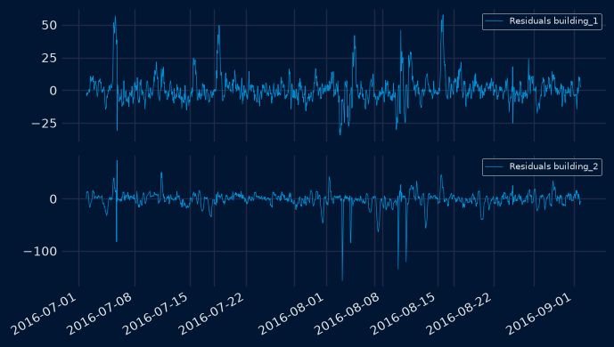

Next, the forecaster is trained with the same training data used in the backtesting, and the validation residuals are stored in it with the [`set_out_sample_residuals()`](https://skforecast.org/latest/api/forecasterrecursivemultiseries#skforecast.recursive._forecaster_recursive_multiseries.ForecasterRecursiveMultiSeries.set_out_sample_residuals) method. Both `y_true` and `y_pred` are dictionaries whose keys are the names of the series, so that each series keeps its own residuals. In addition, the forecaster stores a random sample of the residuals of all the series under the key `_unknown_level`, which is used to estimate intervals for series not seen during training.

```python
# Store out-of-sample residuals in the forecaster
# ==============================================================================
forecaster.fit(
    series            = data_train[series],
    exog              = data_train[exog_features],
    suppress_warnings = True
)
forecaster.set_out_sample_residuals(
    y_true = {k: data_val[k] for k in series},
    y_pred = {k: v for k, v in predictions_val.groupby('level')['pred']}
)
```

# Store out-of-sample residuals in the forecaster # ============================================================================== forecaster.fit( series = data_train[series], exog = data_train[exog_features], suppress_warnings = True ) forecaster.set_out_sample_residuals( y_true = {k: data_val[k] for k in series}, y_pred = {k: v for k, v in predictions_val.groupby('level')['pred']} )

**✏️ Note**

When the out-of-sample residuals are stored in the forecaster, they are binned according to the predicted value to which they correspond (10 bins by default, as shown below). Later, when the intervals are estimated with `use_binned_residuals=True`, only the residuals of the bin where the prediction falls are used: in bootstrapping, the residuals are sampled from that bin; in conformal prediction, the correction factor is calculated from that bin. In this way, the width of the intervals adapts to the magnitude of the prediction, which is useful when the size of the errors depends on the predicted value. For more information about how residuals are used in interval estimation, visit Probabilistic forecasting: Bootstrapped residuals and Probabilistic forecasting: Conformal prediction.

```python
# Intervals of the residual bins (conditioned on predicted values) for each level
# ==============================================================================
for k, v in forecaster.binner_intervals_.items():
    print(k)
    pprint(v)
    print("")
```

# Intervals of the residual bins (conditioned on predicted values) for each level # ============================================================================== for k, v in forecaster.binner_intervals_.items(): print(k) pprint(v) print("")

```
building_1
{0: (165.20499932654647, 188.29862772750283),
 1: (188.29862772750283, 192.71291989855519),
 2: (192.71291989855519, 196.50159701655218),
 3: (196.50159701655218, 200.36282013339397),
 4: (200.36282013339397, 205.78088677076306),
 5: (205.78088677076306, 213.05048123203005),
 6: (213.05048123203005, 223.81891494270874),
 7: (223.81891494270874, 247.23223476967067),
 8: (247.23223476967067, 257.59956347695794),
 9: (257.59956347695794, 292.5578128598947)}

building_2
{0: (185.31199428441397, 221.82899062428837),
 1: (221.82899062428837, 227.77775215345284),
```

[output cut: 20 more lines]

```python
# Distribution of the residuals by bin and level
# ==============================================================================
flierprops = dict(marker='o', markerfacecolor='gray', markersize=5, linestyle='none')
levels = list(forecaster.out_sample_residuals_by_bin_)
fig, axs = plt.subplots(len(levels), 1, figsize=(7, 7), sharex=True, sharey=True)
for i, level in enumerate(levels):
    residuals_by_bin = forecaster.out_sample_residuals_by_bin_[level]
    residuals_by_bin_df = pd.DataFrame(
        {k: pd.Series(v) for k, v in residuals_by_bin.items()}
    )
    residuals_by_bin_df.boxplot(ax=axs[i], flierprops=flierprops)
    axs[i].set_title(level, fontsize=10)
    axs[i].set_ylabel("Residual", fontsize=8)

axs[-1].set_xlabel("Bin", fontsize=8)
fig.suptitle("Distribution of residuals by bin", fontsize=12)
fig.tight_layout()
```

# Distribution of the residuals by bin and level # ============================================================================== flierprops = dict(marker='o', markerfacecolor='gray', markersize=5, linestyle='none') levels = list(forecaster.out_sample_residuals_by_bin_) fig, axs = plt.subplots(len(levels), 1, figsize=(7, 7), sharex=True, sharey=True) for i, level in enumerate(levels): residuals_by_bin = forecaster.out_sample_residuals_by_bin_[level] residuals_by_bin_df = pd.DataFrame( {k: pd.Series(v) for k, v in residuals_by_bin.items()} ) residuals_by_bin_df.boxplot(ax=axs[i], flierprops=flierprops) axs[i].set_title(level, fontsize=10) axs[i].set_ylabel("Residual", fontsize=8) axs[-1].set_xlabel("Bin", fontsize=8) fig.suptitle("Distribution of residuals by bin", fontsize=12) fig.tight_layout()

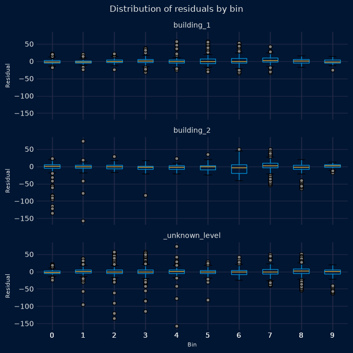

**✏️ Note**

Two arguments control the use of residuals in [`predict_interval()`](https://skforecast.org/latest/api/forecasterrecursivemultiseries#skforecast.recursive._forecaster_recursive_multiseries.ForecasterRecursiveMultiSeries.predict_interval) and [`backtesting_forecaster_multiseries()`](https://skforecast.org/latest/api/model_selection#skforecast.model_selection._validation.backtesting_forecaster_multiseries):

- `use_in_sample_residuals`: If `True`, the in-sample residuals are used to compute the prediction intervals. Since these residuals are obtained from the training set, they are always available, but usually lead to overoptimistic intervals. If `False`, the out-of-sample residuals (calibration) are used to calculate the prediction intervals. These residuals are obtained from the validation/calibration set and are only available if the [`set_out_sample_residuals()`](https://skforecast.org/latest/api/forecasterrecursivemultiseries#skforecast.recursive._forecaster_recursive_multiseries.ForecasterRecursiveMultiSeries.set_out_sample_residuals) method has been called. It is recommended to use out-of-sample residuals to achieve the desired coverage.
- `use_binned_residuals`: If `False`, all the residuals are used regardless of the predicted value: a single correction factor is applied to all the predictions (conformal), or the residuals are sampled from the whole set (bootstrapping). If `True`, only the residuals of the bin where the prediction falls are used, so the correction factor (conformal) or the sampled residuals (bootstrapping) depend on the predicted value. This produces intervals whose width adapts to the magnitude of the prediction.

## Intervals using conformal prediction

The forecaster is now evaluated on the test set with a backtesting of 24-step folds. The argument `interval = [0.1, 0.9]` requests the 0.1 and 0.9 quantiles, that is, an interval with a nominal coverage of 80%. The intervals are calculated with `interval_method = "conformal"`, using the out-of-sample residuals conditioned on the predicted value.

Two metrics are used to evaluate the intervals on the test set:

- **Empirical coverage**: proportion of observed values that fall within the interval, calculated with [`calculate_coverage`](https://skforecast.org/latest/api/metrics#skforecast.metrics.calculate_coverage). Well-calibrated intervals have a coverage close to the nominal one (80%).
- **Area**: sum of the widths of the interval over all the predicted steps. For a similar coverage, a smaller area means narrower, more informative intervals.

The intervals are plotted with [`plot_prediction_intervals`](https://skforecast.org/latest/api/plot#skforecast.plot.plot.plot_prediction_intervals).

**✏️ Note**

Since `initial_train_size` covers the training and validation partitions, the backtesting retrains the forecaster with both of them before predicting the test set, so the final model uses all the data available before the test period. The out-of-sample residuals and their bins, stored with `set_out_sample_residuals()`, are kept after this refit, so the intervals are still calibrated with the validation residuals.

```python
# Backtesting with conformal prediction intervals
# ==============================================================================
cv = TimeSeriesFold(
    initial_train_size = len(data.loc[:end_validation, :]),
    steps              = 24,
)

metric, predictions_conformal = backtesting_forecaster_multiseries(
    forecaster              = forecaster,
    series                  = data[series],
    exog                    = data[exog_features],
    cv                      = cv,
    metric                  = "mean_absolute_error",
    interval                = [0.1, 0.9],
    interval_method         = "conformal",
    use_in_sample_residuals = False,  # Use out-of-sample residuals
    use_binned_residuals    = True,   # Adaptive intervals
    suppress_warnings       = True
)
predictions_conformal
```

# Backtesting with conformal prediction intervals # ============================================================================== cv = TimeSeriesFold( initial_train_size = len(data.loc[:end_validation, :]), steps = 24, ) metric, predictions_conformal = backtesting_forecaster_multiseries( forecaster = forecaster, series = data[series], exog = data[exog_features], cv = cv, metric = "mean_absolute_error", interval = [0.1, 0.9], interval_method = "conformal", use_in_sample_residuals = False, # Use out-of-sample residuals use_binned_residuals = True, # Adaptive intervals suppress_warnings = True ) predictions_conformal

100%29/29 [00:00<00:00, 372.32it/s]

|  | level | fold | pred | lower_bound | upper_bound |
| --- | --- | --- | --- | --- | --- |
| 2016-09-02 00:00:00 | building_1 | 0 | 198.821665 | 189.903492 | 207.739838 |
| 2016-09-02 00:00:00 | building_2 | 0 | 204.475048 | 194.299621 | 214.650475 |
| 2016-09-02 01:00:00 | building_1 | 0 | 195.874267 | 188.227810 | 203.520723 |
| 2016-09-02 01:00:00 | building_2 | 0 | 202.250982 | 192.075555 | 212.426409 |
| 2016-09-02 02:00:00 | building_1 | 0 | 192.720768 | 185.074312 | 200.367225 |
| ... | ... | ... | ... | ... | ... |
| 2016-09-29 22:00:00 | building_2 | 27 | 212.441112 | 202.265685 | 222.616539 |
| 2016-09-29 23:00:00 | building_1 | 27 | 205.382013 | 194.846273 | 215.917753 |
| 2016-09-29 23:00:00 | building_2 | 27 | 206.619372 | 196.443945 | 216.794799 |
| 2016-09-30 00:00:00 | building_1 | 28 | 200.266870 | 191.348697 | 209.185043 |
| 2016-09-30 00:00:00 | building_2 | 28 | 203.849044 | 193.673617 | 214.024471 |

1346 rows × 5 columns

```python
# Function to plot intervals and calculate coverage for each level
# ==============================================================================
def plot_intervals_and_coverage(predictions, y_true):
    """
    Plot the prediction intervals of each level and print their empirical
    coverage and area.
    """
    plt.rcParams["lines.linewidth"] = 1
    for level in predictions["level"].unique():
        print(f"\nLevel: {level}")
        predictions_level = (
            predictions[predictions["level"] == level].drop(columns="level")
        )

        # Plot intervals
        fig, ax = plt.subplots(figsize=(7, 3))
        plot_prediction_intervals(
            predictions     = predictions_level,
            y_true          = y_true[[level]],
            target_variable = level,
            initial_x_zoom  = None,
            title           = "Prediction intervals",
            xaxis_title     = "",
            yaxis_title     = level,
            ax              = ax
        )
        ax.legend(loc="upper left", fontsize=7)
        fill_between_obj = ax.collections[0]
        fill_between_obj.set_facecolor("white")
        fill_between_obj.set_alpha(0.3)

        # Empirical coverage of the interval
        coverage = calculate_coverage(
            y_true      = y_true[level],
            lower_bound = predictions_level["lower_bound"],
            upper_bound = predictions_level["upper_bound"]
        )
        print(f"Empirical coverage of the interval: {round(100 * coverage, 2)} %")

        # Area of the interval
        area = (predictions_level["upper_bound"] - predictions_level["lower_bound"]).sum()
        print(f"Area of the interval: {round(area, 2)}")


plot_intervals_and_coverage(predictions_conformal, y_true=data_test)
```

# Function to plot intervals and calculate coverage for each level # ============================================================================== def plot_intervals_and_coverage(predictions, y_true): """ Plot the prediction intervals of each level and print their empirical coverage and area. """ plt.rcParams["lines.linewidth"] = 1 for level in predictions["level"].unique(): print(f"\nLevel: {level}") predictions_level = ( predictions[predictions["level"] == level].drop(columns="level") ) # Plot intervals fig, ax = plt.subplots(figsize=(7, 3)) plot_prediction_intervals( predictions = predictions_level, y_true = y_true[[level]], target_variable = level, initial_x_zoom = None, title = "Prediction intervals", xaxis_title = "", yaxis_title = level, ax = ax ) ax.legend(loc="upper left", fontsize=7) fill_between_obj = ax.collections[0] fill_between_obj.set_facecolor("white") fill_between_obj.set_alpha(0.3) # Empirical coverage of the interval coverage = calculate_coverage( y_true = y_true[level], lower_bound = predictions_level["lower_bound"], upper_bound = predictions_level["upper_bound"] ) print(f"Empirical coverage of the interval: {round(100 * coverage, 2)} %") # Area of the interval area = (predictions_level["upper_bound"] - predictions_level["lower_bound"]).sum() print(f"Area of the interval: {round(area, 2)}") plot_intervals_and_coverage(predictions_conformal, y_true=data_test)

```
Level: building_1
Empirical coverage of the interval: 83.95 %
Area of the interval: 13485.99

Level: building_2
Empirical coverage of the interval: 83.06 %
Area of the interval: 17790.12
```

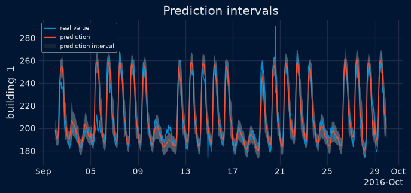

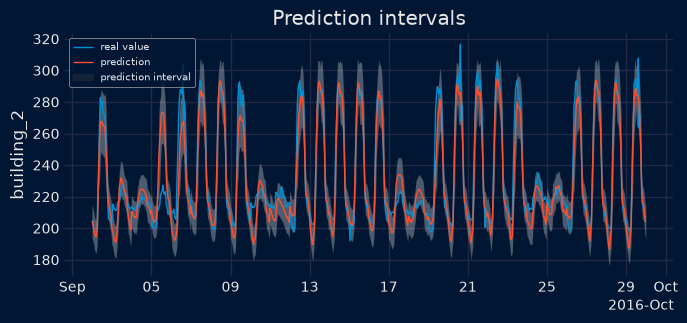

With conformal prediction, the empirical coverage on the test set is 83.95% for `building_1` and 83.06% for `building_2`, slightly above the nominal coverage of 80%. The intervals are slightly conservative, but reasonably well calibrated. Their areas are 13,485.99 and 17,790.12, respectively. The larger area of `building_2` is consistent with its larger error in the validation backtesting (mean absolute error of 9.10 versus 6.56 for `building_1`).

## Intervals using bootstrapped residuals

The same process is repeated, but this time the bootstrapping method is used instead of the conformal method. With `n_boot = 150`, 150 alternative prediction paths are simulated by adding to the predictions residuals sampled from the bin of each prediction. The bounds of the interval are the 0.1 and 0.9 quantiles of these paths at each step.

```python
# Backtesting with prediction intervals using bootstrapping
# ==============================================================================
# The cv object of the conformal backtesting is reused
metric, predictions_bootstrapping = backtesting_forecaster_multiseries(
    forecaster              = forecaster,
    series                  = data[series],
    exog                    = data[exog_features],
    cv                      = cv,
    metric                  = "mean_absolute_error",
    interval                = [0.1, 0.9],
    interval_method         = "bootstrapping",
    n_boot                  = 150,
    use_in_sample_residuals = False,  # Use out-of-sample residuals
    use_binned_residuals    = True,   # Residuals conditioned on predicted values
    suppress_warnings       = True
)
predictions_bootstrapping
```

# Backtesting with prediction intervals using bootstrapping # ============================================================================== # The cv object of the conformal backtesting is reused metric, predictions_bootstrapping = backtesting_forecaster_multiseries( forecaster = forecaster, series = data[series], exog = data[exog_features], cv = cv, metric = "mean_absolute_error", interval = [0.1, 0.9], interval_method = "bootstrapping", n_boot = 150, use_in_sample_residuals = False, # Use out-of-sample residuals use_binned_residuals = True, # Residuals conditioned on predicted values suppress_warnings = True ) predictions_bootstrapping

100%29/29 [00:00<00:00, 64.10it/s]

|  | level | fold | pred | lower_bound | upper_bound |
| --- | --- | --- | --- | --- | --- |
| 2016-09-02 00:00:00 | building_1 | 0 | 198.821665 | 192.420494 | 209.905264 |
| 2016-09-02 00:00:00 | building_2 | 0 | 204.475048 | 194.847599 | 215.465116 |
| 2016-09-02 01:00:00 | building_1 | 0 | 195.874267 | 186.090498 | 213.503387 |
| 2016-09-02 01:00:00 | building_2 | 0 | 202.250982 | 188.650391 | 218.721453 |
| 2016-09-02 02:00:00 | building_1 | 0 | 192.720768 | 183.154797 | 218.639839 |
| ... | ... | ... | ... | ... | ... |
| 2016-09-29 22:00:00 | building_2 | 27 | 212.441112 | 192.717301 | 234.768066 |
| 2016-09-29 23:00:00 | building_1 | 27 | 205.382013 | 193.015801 | 252.393190 |
| 2016-09-29 23:00:00 | building_2 | 27 | 206.619372 | 183.959878 | 230.196653 |
| 2016-09-30 00:00:00 | building_1 | 28 | 200.266870 | 193.766870 | 209.104257 |
| 2016-09-30 00:00:00 | building_2 | 28 | 203.849044 | 193.687843 | 215.279858 |

1346 rows × 5 columns

```python
# Plot intervals and calculate coverage for each level
# ==============================================================================
plot_intervals_and_coverage(predictions_bootstrapping, y_true=data_test)
```

# Plot intervals and calculate coverage for each level # ============================================================================== plot_intervals_and_coverage(predictions_bootstrapping, y_true=data_test)

```
Level: building_1
Empirical coverage of the interval: 96.29 %
Area of the interval: 31297.34

Level: building_2
Empirical coverage of the interval: 97.92 %
Area of the interval: 37029.52
```

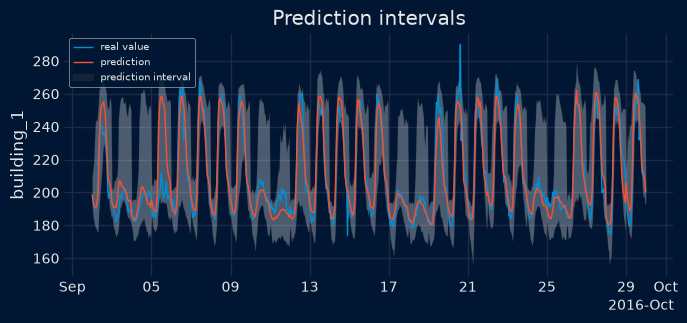

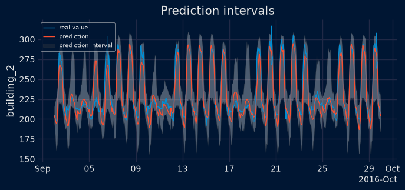

With bootstrapping, the empirical coverage is 96.29% for `building_1` and 97.92% for `building_2`, well above the nominal 80%. The intervals are overly conservative: their areas (31,297.34 and 37,029.52) are about 2.3 and 2.1 times larger than those obtained with conformal prediction.

A likely reason is the way the residuals are used. The out-of-sample residuals come from a backtesting with folds of 24 steps, so each residual already contains the error accumulated over up to 24 predicted steps. In recursive bootstrapping, a residual is added at every step and, since each simulated value is used as a lag to predict the following steps, the noise propagates along the horizon. Part of the accumulated error is therefore counted twice. Conformal prediction, instead, adds the correction factor once per step, without propagating it. In addition, as discussed in the bootstrapped residuals user guide, the residuals are obtained with a model trained only with the training partition, while the final model is also trained with the validation data and is expected to make smaller errors.

In this example, conformal prediction provides intervals that are much closer to the nominal coverage and considerably narrower.

## Forecasting intervals for unknown series

The [`ForecasterRecursiveMultiSeries`](https://skforecast.org/latest/api/forecasterrecursivemultiseries) class allows forecasting series not seen during training, with the only requirement that at least `window_size` observations of the new series are available (145 in this example, the largest lag). These observations are passed through the `last_window` argument of [`predict_interval()`](https://skforecast.org/latest/api/forecasterrecursivemultiseries#skforecast.recursive._forecaster_recursive_multiseries.ForecasterRecursiveMultiSeries.predict_interval).

In this example, the new series is simulated by adding a small amount of Gaussian noise to the last observations of `building_1` in the validation partition. Two warnings are raised:

- The identifier of the new series was not seen during training, so it is encoded as `NaN`. This works because LightGBM handles missing values natively; with an estimator that does not accept `NaN`, the prediction would fail.
- There are no residuals for the new series, so the intervals are calculated with the residuals stored under the key `_unknown_level`, a random sample of the residuals of all the known series.

```python
# Predictions for an unknown series
# ==============================================================================
# Simulate last_window of the new series
rng = np.random.default_rng(123)
len_last_window = forecaster.window_size
last_window = pd.DataFrame({
    'new_series': (
        data_val['building_1'].iloc[-len_last_window:]
        + rng.normal(0, 0.1, len_last_window)
    )
})

forecaster.predict_interval(
    steps                   = 24,
    last_window             = last_window,
    exog                    = data_test[exog_features],
    method                  = 'conformal',
    interval                = [0.1, 0.9],
    use_in_sample_residuals = False
)
```

# Predictions for an unknown series # ============================================================================== # Simulate last_window of the new series rng = np.random.default_rng(123) len_last_window = forecaster.window_size last_window = pd.DataFrame({ 'new_series': ( data_val['building_1'].iloc[-len_last_window:] + rng.normal(0, 0.1, len_last_window) ) }) forecaster.predict_interval( steps = 24, last_window = last_window, exog = data_test[exog_features], method = 'conformal', interval = [0.1, 0.9], use_in_sample_residuals = False )

```
╭──────────────────────────────── UnknownLevelWarning ─────────────────────────────────╮
│ `levels` {'new_series'} were not included in training. Unknown levels are encoded as │
│ NaN, which may cause the prediction to fail if the estimator does not accept NaN     │
│ values.                                                                              │
│                                                                                      │
│ Category : skforecast.exceptions.UnknownLevelWarning                                 │
│ Location :                                                                           │
│ /Users/javier.escobar/code/github/skforecast/skforecast/utils/utils.py:1491          │
│ Suppress : warnings.simplefilter('ignore', category=UnknownLevelWarning)             │
╰──────────────────────────────────────────────────────────────────────────────────────╯
```

```
╭──────────────────────────────── UnknownLevelWarning ─────────────────────────────────╮
│ `levels` {'new_series'} are not present in                                           │
│ `forecaster.out_sample_residuals_by_bin_`. A random sample of the residuals from     │
│ other levels will be used. This can lead to inaccurate intervals for the unknown     │
│ levels. Otherwise, Use the `set_out_sample_residuals()` method before predicting to  │
│ set the residuals for these levels.                                                  │
│                                                                                      │
│ Category : skforecast.exceptions.UnknownLevelWarning                                 │
│ Location :                                                                           │
│ /Users/javier.escobar/code/github/skforecast/skforecast/utils/utils.py:1925          │
│ Suppress : warnings.simplefilter('ignore', category=UnknownLevelWarning)             │
╰──────────────────────────────────────────────────────────────────────────────────────╯
```

|  | level | pred | lower_bound | upper_bound |
| --- | --- | --- | --- | --- |
| 2016-09-02 00:00:00 | new_series | 199.294313 | 190.929439 | 207.659187 |
| 2016-09-02 01:00:00 | new_series | 196.150552 | 187.785678 | 204.515426 |
| 2016-09-02 02:00:00 | new_series | 192.871179 | 184.506305 | 201.236053 |
| 2016-09-02 03:00:00 | new_series | 191.774456 | 185.001310 | 198.547603 |
| 2016-09-02 04:00:00 | new_series | 191.367051 | 184.593904 | 198.140198 |
| 2016-09-02 05:00:00 | new_series | 191.546486 | 184.773339 | 198.319632 |
| 2016-09-02 06:00:00 | new_series | 192.314902 | 185.541755 | 199.088049 |
| 2016-09-02 07:00:00 | new_series | 198.286753 | 189.921879 | 206.651627 |
| 2016-09-02 08:00:00 | new_series | 215.400580 | 203.870512 | 226.930649 |
| 2016-09-02 09:00:00 | new_series | 236.501373 | 224.016532 | 248.986214 |
| 2016-09-02 10:00:00 | new_series | 249.815882 | 234.829805 | 264.801959 |
| 2016-09-02 11:00:00 | new_series | 252.806961 | 237.820885 | 267.793038 |
| 2016-09-02 12:00:00 | new_series | 255.773568 | 240.787491 | 270.759644 |
| 2016-09-02 13:00:00 | new_series | 255.838280 | 240.852204 | 270.824357 |
| 2016-09-02 14:00:00 | new_series | 255.514821 | 240.528744 | 270.500898 |
| 2016-09-02 15:00:00 | new_series | 253.333388 | 238.347311 | 268.319464 |
| 2016-09-02 16:00:00 | new_series | 249.001096 | 234.015020 | 263.987173 |
| 2016-09-02 17:00:00 | new_series | 238.398423 | 225.913582 | 250.883264 |
| 2016-09-02 18:00:00 | new_series | 227.150036 | 215.931363 | 238.368710 |
| 2016-09-02 19:00:00 | new_series | 215.810711 | 204.280643 | 227.340780 |
| 2016-09-02 20:00:00 | new_series | 210.391208 | 199.368534 | 221.413881 |
| 2016-09-02 21:00:00 | new_series | 209.709003 | 198.686329 | 220.731676 |
| 2016-09-02 22:00:00 | new_series | 208.672495 | 197.649822 | 219.695169 |
| 2016-09-02 23:00:00 | new_series | 204.863147 | 193.840474 | 215.885821 |

## Probabilistic forecasting in production

Once the forecaster is deployed, the out-of-sample residuals should be refreshed periodically with the most recent errors of the model. A simple workflow is to keep the predictions made by the deployed forecaster (with the same horizon used in production) and, once the real values are observed, store the new residuals with [`set_out_sample_residuals()`](https://skforecast.org/latest/api/forecasterrecursivemultiseries#skforecast.recursive._forecaster_recursive_multiseries.ForecasterRecursiveMultiSeries.set_out_sample_residuals). With `append=False` (default), the stored residuals are replaced; with `append=True`, the new residuals are added to the existing ones.

```
# Illustrative example: y_pred_recent contains the predictions made by the
# deployed forecaster over the last weeks and y_true_recent the values observed
# afterwards, both as dictionaries {series_name: pandas Series}
forecaster.set_out_sample_residuals(
    y_true = y_true_recent,
    y_pred = y_pred_recent,
    append = False  # True to add the new residuals to the existing ones
)
```

Calling `fit()` removes the stored out-of-sample residuals, so they must be set again every time the forecaster is retrained.

**⚠ Warning**

The correct estimation of prediction intervals with conformal methods depends on the residuals being representative of future errors. For this reason, calibration residuals should be used. However, the dynamics of the series and models can change over time, so it is important to monitor and regularly update the residuals. It can be done easily using the [`set_out_sample_residuals()`](https://skforecast.org/latest/api/forecasterrecursivemultiseries#skforecast.recursive._forecaster_recursive_multiseries.ForecasterRecursiveMultiSeries.set_out_sample_residuals) method.

## Key takeaways

- The probabilistic forecasting methods of skforecast can be applied to global models: a single `ForecasterRecursiveMultiSeries` estimates intervals for every series, and each series keeps its own residuals and bins.
- The intervals must be built with out-of-sample residuals, obtained by backtesting on a validation (calibration) partition with the same horizon used later. In-sample residuals lead to overconfident intervals.
- With `use_binned_residuals=True`, the residuals are conditioned on the predicted value, so the width of the intervals adapts to the magnitude of the prediction.
- In this example, conformal prediction achieves a coverage close to the nominal 80% (83.95% and 83.06%), while bootstrapping produces intervals about twice as wide and overly conservative (96.29% and 97.92%), since the multi-step residuals are propagated recursively along the horizon.
- Series not seen during training can also be forecast with intervals, using a random sample of the residuals of all the known series (`_unknown_level`).
- The empirical coverage must always be validated with backtesting, and the residuals should be refreshed periodically in production and after every refit.